# CITS4009 Computational Data Analysis

Project 1 - Exploratory Data Analysis

Kaiqi LIANG (23344153)

Semester 2, 2022

# 1 Introduction

The dataset for this project is Australia’s data science job listings for August 2022 which can be downloaded on [Kaggle](https://www.kaggle.com/datasets/nadzmiagthomas/australia-data-science-jobs). It was scrapped from [Glassdoor](https://www.glassdoor.com.au) which is a website where current and former employees anonymously review companies.

# 2 Setup

Load libraries and data.

```r
library(ggplot2)
library(WVPlots)
library(ozmaps)
library(sf)
library(dplyr)
library(gridExtra)
library(knitr)

df <- read.csv(file = "AustraliaDataScienceJobs.csv", header = TRUE)

# Replace empty strings with NA
df[df == ""] <- NA
```

Code to allow truncating text output especially for `str()` and `head()` functions.

```r
# save the built-in output hook
hook_output <- knitr::knit_hooks$get("output")

# set a new output hook to truncate text output
knitr::knit_hooks$set(output = function(x, options) {
  if (!is.null(n <- options$out.lines)) {
    x <- xfun::split_lines(x)
    if (length(x) > n) {
      # truncate the output
      x <- c(head(x, n), "....\n")
    }
    x <- paste(x, collapse = "\n")
  }
  hook_output(x, options)
})
```

Set up a custom theme so all the plots can be standardised as well as having the ability to customise to their needs.

```r
custom_theme <- function(
  title_y_r_margin = 10,
  title_x_t_margin = 10,
  title_b_margin = 20,
  title_size = 20,
  label_size = 16,
  font_size = 14
) {
  theme(
    axis.title.x = element_text(margin = margin(t = title_x_t_margin)),
    axis.title.y = element_text(margin = margin(r = title_y_r_margin)),
    axis.title = element_text(size = label_size),
    plot.title = element_text(
      size = title_size,
      margin = margin(b = title_b_margin)
    ),
    text = element_text(size = font_size)
  )
}
```

# 3 Data Cleaning and Transformation

## 3.1 Data Exploratory, Cleaning

Use `str()` to have a glance at the data.

```r
str(df)
```

```
## 'data.frame':    2088 obs. of  53 variables:
##  $ Job.Title                    : chr  "Analyst" "Clinical Research Associate" "Clinical Research Associate" "Clinical Research Associate" ...
##  $ Job.Location                 : chr  "Melbourne" "Mulgrave" "Mulgrave" "Mulgrave" ...
##  $ Company                      : chr  "ANZ Banking Group" "Bristol Myers Squibb" "Bristol Myers Squibb" "Bristol Myers Squibb" ...
##  $ Url                          : chr  "https://www.glassdoor.com.au/partner/jobListing.htm?pos=101&ao=1110586&s=58&guid=000001826eaa3c8799de46d597a14f"| __truncated__ "https://www.glassdoor.com.au/partner/jobListing.htm?pos=201&ao=1110586&s=58&guid=000001826eaa43e3934cf1dcd2d0c4"| __truncated__ …
##  $ Estimate.Base.Salary         : int  95917 96555 96555 96555 115631 115631 62718 115631 212000 212000 ...
##  $ Low.Estimate                 : int  80000 79000 79000 79000 94000 94000 62000 94000 173000 173000 ...
##  $ High.Estimate                : int  115000 118000 118000 118000 143000 143000 63000 143000 251000 251000 ...
##  $ Company.Size                 : chr  "10000+ Employees" "10000+ Employees" "10000+ Employees" "10000+ Employees" ...
##  $ Company.Type                 : chr  "Company - Public" "Company - Public" "Company - Public" "Company - Public" ...
##  $ Company.Sector               : chr  "Finance" "Pharmaceutical & Biotechnology" "Pharmaceutical & Biotechnology" "Pharmaceutical & Biotechnology" ...
##  $ Company.Founded              : num  1835 1858 1858 1858 1835 ...
##  $ Company.Industry             : chr  "Banking & Lending" "Biotech & Pharmaceuticals" "Biotech & Pharmaceuticals" "Biotech & Pharmaceuticals" ...
##  $ Company.Revenue              : chr  "Unknown / Non-Applicable" "$10+ billion (USD)" "$10+ billion (USD)" "$10+ billion (USD)" ...
##  $ Job.Descriptions             : chr  "-\nBuild a rewarding career in an innovative and collaborative environment\nHighly engaged culture aiming to su"| __truncated__ "At Bristol Myers Squibb, we are inspired by a single vision – transforming patients’ lives through science. In "| __truncated__ …
```

[output cut: 16 more lines]

There are 2088 observations of 53 variables.

## 3.2 Renaming Variables

There are a couple typos in the variable names let’s fix that first, and some of them are very verbose which we can simplify.

```r
df <- rename(df,
  Number.of.Rater = Companny.Number.of.Rater,
  Career.Opportunities = Company.Career.Opportinities,
  Culture.and.Values = Company.Culture.and.Values,
  Senior.Management = Company.Senior.Management,
  Work.Life.Balance = Company.Work.Life.Balance,
  Friend.Recommendation = Company.Friend.Reccomendation
)
```

## 3.3 Dropping Columns

The variable `Country` should be all `Australia` because this is an Australia’s data science jobs dataset, all the job listings should be in Australia, otherwise it is not valid.

```r
any(df$Country != "Australia")
```

```
## [1] FALSE
```

Confirmed that there is no invalid data for the `Country` variable, then it is essentially useless as all the observations are the same, so we should be able to drop it, along with some other columns that are just long chunk of text, `Job Descriptions` and `Url` in particular which are also not that useful to us.

```r
df <- df[!names(df) %in% c("Country", "Job.Descriptions", "Url")]
```

## 3.4 Type Conversion

All the variables that end with `_yn` contain only `1`s and `0`s which should be converted to `logical`.

```r
skill_columns <- grep("_yn", names(df))
df[skill_columns] <- sapply(df[skill_columns], function(col) {
  as.logical(col)
})
```

Then inspect the data again using `head()` to look at the first 3 observations.

```r
head(df, 3)
```

```
##                     Job.Title Job.Location              Company
## 1                     Analyst    Melbourne    ANZ Banking Group
## 2 Clinical Research Associate     Mulgrave Bristol Myers Squibb
## 3 Clinical Research Associate     Mulgrave Bristol Myers Squibb
##   Estimate.Base.Salary Low.Estimate High.Estimate     Company.Size
## 1                95917        80000        115000 10000+ Employees
## 2                96555        79000        118000 10000+ Employees
## 3                96555        79000        118000 10000+ Employees
##       Company.Type                 Company.Sector Company.Founded
## 1 Company - Public                        Finance            1835
## 2 Company - Public Pharmaceutical & Biotechnology            1858
## 3 Company - Public Pharmaceutical & Biotechnology            1858
##            Company.Industry          Company.Revenue Company.Rating
## 1         Banking & Lending Unknown / Non-Applicable            3.7
## 2 Biotech & Pharmaceuticals       $10+ billion (USD)            3.9
## 3 Biotech & Pharmaceuticals       $10+ billion (USD)            3.9
##   Friend.Recommendation Company.CEO.Approval Number.of.Rater
## 1                    71                   75             354
## 2                    76                   82            1165
## 3                    76                   82            1165
##   Career.Opportunities Compensation.and.Benefits Culture.and.Values
## 1                  3.9                       3.7                4.1
## 2                  3.6                       3.9                3.8
## 3                  3.6                       3.9                3.8
##   Senior.Management Work.Life.Balance    State python_yn  r_yn sql_yn java_yn
## 1               3.7               4.0 Victoria     FALSE FALSE  FALSE   FALSE
## 2               3.5               3.7 Victoria     FALSE FALSE  FALSE   FALSE
## 3               3.5               3.7 Victoria     FALSE FALSE  FALSE   FALSE
....
```

Looking much cleaner now.

## 3.5 Missing Values

Count the missing values in each variable.

```r
count_missing <- function() {
  na_counts <- sapply(df, function(col) length(which(is.na(col))))
  na_counts[which(na_counts > 0)]
}
count_missing()
```

```
##                 Job.Title              Company.Size              Company.Type
##                         3                       181                       181
##            Company.Sector           Company.Founded          Company.Industry
##                       567                       890                       567
##           Company.Revenue            Company.Rating     Friend.Recommendation
##                       181                       311                       356
##      Company.CEO.Approval           Number.of.Rater      Career.Opportunities
##                       764                       311                       318
## Compensation.and.Benefits        Culture.and.Values         Senior.Management
##                       318                       318                       318
##         Work.Life.Balance
##                       318
```

The 3 jobs that do not even have a `Title` should be dropped.

```r
df <- df[!is.na(df$Job.Title), ]
count_missing()
```

```
##              Company.Size              Company.Type            Company.Sector
##                       180                       180                       566
##           Company.Founded          Company.Industry           Company.Revenue
##                       889                       566                       180
##            Company.Rating     Friend.Recommendation      Company.CEO.Approval
##                       310                       355                       763
##           Number.of.Rater      Career.Opportunities Compensation.and.Benefits
##                       310                       317                       317
##        Culture.and.Values         Senior.Management         Work.Life.Balance
##                       317                       317                       317
```

The variable `Company Founded` is the year when the company is founded in and `Company CEO Approval` is the percentage of employees who approve their CEO. They both have around 40% of missing values, the first one is probably because the companies did not enter the year founded and the second one might be because the employees are scared to say about their CEO. Due to these reasons they do not have enough useful information to be kept.

```r
df <- df[!names(df) %in% c("Company.Founded", "Company.CEO.Approval")]
count_missing()
```

```
##              Company.Size              Company.Type            Company.Sector
##                       180                       180                       566
##          Company.Industry           Company.Revenue            Company.Rating
##                       566                       180                       310
##     Friend.Recommendation           Number.of.Rater      Career.Opportunities
##                       355                       310                       317
## Compensation.and.Benefits        Culture.and.Values         Senior.Management
##                       317                       317                       317
##         Work.Life.Balance
##                       317
```

All 3 variables `Company Size`, `Company Type` and `Company Revenue` are missing 180 observations, let’s see if they are the same ones.

```r
summary(cbind(
  Company.Size = which(is.na(df$Company.Size)),
  Company.Type = which(is.na(df$Company.Type)),
  Company.Revenue = which(is.na(df$Company.Revenue))
))
```

```
##   Company.Size     Company.Type    Company.Revenue
##  Min.   :  21.0   Min.   :  21.0   Min.   :  21.0
##  1st Qu.: 827.8   1st Qu.: 827.8   1st Qu.: 827.8
##  Median :1105.5   Median :1105.5   Median :1105.5
##  Mean   :1151.4   Mean   :1151.4   Mean   :1151.4
##  3rd Qu.:1554.8   3rd Qu.:1554.8   3rd Qu.:1554.8
##  Max.   :2081.0   Max.   :2081.0   Max.   :2081.0
```

The missing values in all 3 columns appear to be in the exact same locations. As it is almost 10% of the total number of observations, let’s see if they are also missing the rating data.

```r
rating_columns <- c(
  "Company.Rating",
  "Career.Opportunities",
  "Compensation.and.Benefits",
  "Culture.and.Values",
  "Senior.Management",
  "Work.Life.Balance",
  "Friend.Recommendation"
)
any(!is.na(df[is.na(df$Company.Size), rating_columns]))
```

```
## [1] FALSE
```

Looks like all the 180 jobs are missing the rating data as well, we can just remove them all.

```r
df <- df[!is.na(df$Company.Size), ]
count_missing()
```

```
##            Company.Sector          Company.Industry            Company.Rating
##                       386                       386                       130
##     Friend.Recommendation           Number.of.Rater      Career.Opportunities
##                       175                       130                       137
## Compensation.and.Benefits        Culture.and.Values         Senior.Management
##                       137                       137                       137
##         Work.Life.Balance
##                       137
```

Now there are still 130 missing values for `Company Rating` and `Number of Rater`, again check whether they’re from the same observations.

```r
any(is.na(df$Company.Rating) != is.na(df$Number.of.Rater))
```

```
## [1] FALSE
```

```r
df$Number.of.Rater[is.na(df$Number.of.Rater)] <- 0
```

Have a peak at the summary of the rating columns.

```r
summary(df[rating_columns])
```

```
##  Company.Rating Career.Opportunities Compensation.and.Benefits
##  Min.   :1.60   Min.   :1.000        Min.   :1.000
##  1st Qu.:3.70   1st Qu.:3.400        1st Qu.:3.400
##  Median :3.90   Median :3.700        Median :3.600
##  Mean   :3.88   Mean   :3.688        Mean   :3.607
##  3rd Qu.:4.10   3rd Qu.:4.000        3rd Qu.:3.900
##  Max.   :5.00   Max.   :5.000        Max.   :5.000
##  NA's   :130    NA's   :137          NA's   :137
##  Culture.and.Values Senior.Management Work.Life.Balance Friend.Recommendation
##  Min.   :1.000      Min.   :1.000     Min.   :1.000     Min.   : 15.00
##  1st Qu.:3.500      1st Qu.:3.100     1st Qu.:3.300     1st Qu.: 68.00
##  Median :3.900      Median :3.500     Median :3.800     Median : 79.00
##  Mean   :3.862      Mean   :3.464     Mean   :3.788     Mean   : 76.39
##  3rd Qu.:4.100      3rd Qu.:3.700     3rd Qu.:4.100     3rd Qu.: 86.00
##  Max.   :5.000      Max.   :5.000     Max.   :5.000     Max.   :100.00
##  NA's   :137        NA's   :137       NA's   :137       NA's   :175
```

```r
df[rating_columns] <- sapply(df[rating_columns], function(column) {
  na <- is.na(column)
  column[na] <- mean(!na)
  column
})
count_missing()
```

```
##   Company.Sector Company.Industry
##              386              386
```

The 2 variables left both have 386 missing values, check one last time if they are from the same observations.

```r
any(is.na(df$Company.Sector) != is.na(df$Company.Industry))
```

```
## [1] FALSE
```

Same result as before, and since they are categorical, their missing values can just be replaced with a new category `Unknown`.

```r
industry_column <- c("Company.Sector", "Company.Industry")
df[industry_column] <- sapply(df[industry_column], function(column) {
  column[is.na(column)] <- "Unknown"
  column
})
count_missing()
```

```
## named integer(0)
```

Finally there are no more missing values.

# 4 Visualisation

## 4.1 Job Locations

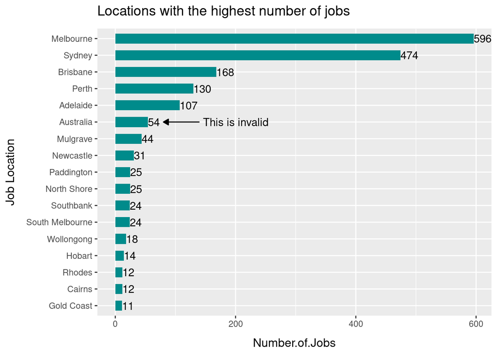

```r
df_locations <- as.data.frame(table(df$Job.Location))
colnames(df_locations) <- c("Location", "Number.of.Jobs")

ggplot(
  df_locations[df_locations$Number.of.Jobs > 10, ],
  aes(
    x = reorder(Location, Number.of.Jobs),
    y = Number.of.Jobs
  ),
) +
  geom_bar(
    stat = "identity",
    width = 0.6,
    fill = "darkcyan"
  ) +
  geom_text(
    aes(label = Number.of.Jobs),
    hjust = 0
  ) +
  labs(
    x = "Job Location",
    title = "Locations with the highest number of jobs"
  ) +
  annotate("text", x = 12, y = 200, label = "This is invalid") +
  annotate("segment", x = 12, y = 140, xend = 12, yend = 80, arrow = arrow(
    type = "closed", length = unit(0.02, "npc")
  )) +
  coord_flip() +
  custom_theme(
    title_b_margin = 10,
    title_size = 14,
    label_size = 12,
    font_size = 11
  )
```

The bar chart shows the locations in decreasing order in the number of job openings where there are at least 10.

The 6th location `Australia` should be changed to `Unknown` as all the other locations are cities other than countries. The reason for this category to appear could either be there are multiple locations in Australia or not sure the exact location.

```r
df$Job.Location[df$Job.Location == "Australia"] <- "Unknown"
```

Let’s look at the distribution in terms of states.

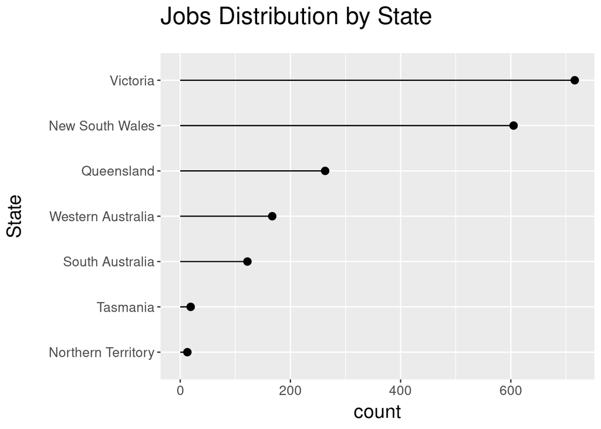

```r
ClevelandDotPlot(
  df,
  "State",
  sort = 1,
  title = "Jobs Distribution by State"
) +
  coord_flip() +
  custom_theme(title_y_r_margin = 20, title_x_t_margin = 5)
```

Just looking at the first 5 locations they are all capital cities of their state which makes the state ranking the same. We can plot the Australia states map to see the jobs distribution more clearly.

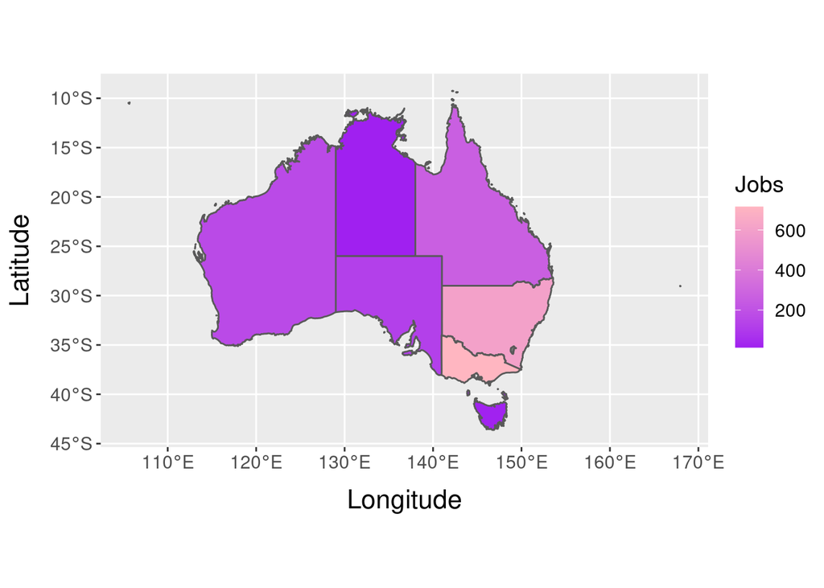

```r
sf_oz <- ozmap_data("states")

jobs <- as.data.frame(table(df$State))
colnames(jobs) <- c("NAME", "Jobs")

ggplot(merge(sf_oz, jobs, all.x = TRUE)) +
  geom_sf(aes(fill = Jobs)) +
  labs(
    x = "Longitude",
    y = "Latitude"
  ) +
  scale_fill_gradient(low = "purple", high = "lightpink") +
  custom_theme()
```

## 4.2 Company

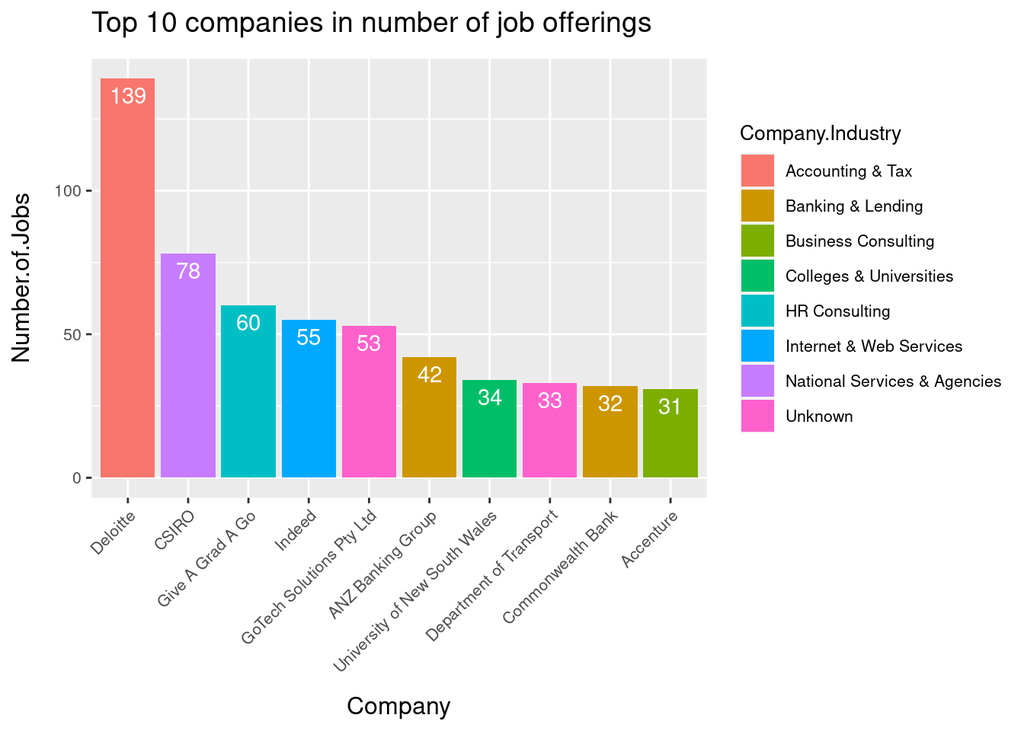

```r
df_companies <- as.data.frame(table(df$Company))
colnames(df_companies) <- c("Company", "Number.of.Jobs")

df_industries <- df[!duplicated(df$Company), c("Company", "Company.Industry")]
df_merge <- merge(df_companies, df_industries)

ggplot(
  head(df_merge[order(-df_merge$Number.of.Jobs), ], 10),
  aes(
    x = reorder(Company, -Number.of.Jobs),
    y = Number.of.Jobs,
    fill = Company.Industry
  )
) +
  geom_bar(
    stat = "identity",
  ) +
  geom_text(
    aes(label = Number.of.Jobs),
    vjust = 1.5,
    colour = "white"
  ) +
  labs(
    x = "Company",
    title = "Top 10 companies in number of job offerings"
  ) +
  theme(axis.text.x = element_text(angle = 45, hjust = 1)) +
  custom_theme(
    title_b_margin = 10,
    title_size = 14,
    label_size = 12,
    font_size = 10
  )
```

The company `Deloitte` which is in the `Accounting & Tax` industry has the most job openings. The number almost doubled the second most company `CSIRO` which is a `National Service & Agencies` and the rest are quite close, this is probably because `Accounting & Tax` requires more data scientists as they deal with numbers the most.

Convert `Company Size` and `Company Revenue` to `factor` so they can be manually ordered based on the categories.

```r
df$Company.Size <- factor(
  df$Company.Size,
  levels = c(
    "Unknown",
    "1 to 50 Employees",
    "51 to 200 Employees",
    "201 to 500 Employees",
    "501 to 1000 Employees",
    "1001 to 5000 Employees",
    "5001 to 10000 Employees",
    "10000+ Employees"
  )
)
df$Company.Revenue <- factor(
  df$Company.Revenue,
  levels = c(
    "Unknown / Non-Applicable",
    "Less than $1 million (USD)",
    "$1 to $5 million (USD)",
    "$5 to $10 million (USD)",
    "$10 to $25 million (USD)",
    "$25 to $50 million (USD)",
    "$50 to $100 million (USD)",
    "$100 to $500 million (USD)",
    "$500 million to $1 billion (USD)",
    "$1 to $2 billion (USD)",
    "$2 to $5 billion (USD)",
    "$5 to $10 billion (USD)",
    "$10+ billion (USD)"
  )
)
summary(df[c("Company.Size", "Company.Revenue")])
```

```
##                   Company.Size                         Company.Revenue
##  10000+ Employees       :538   Unknown / Non-Applicable        :699
##  1001 to 5000 Employees :372   $10+ billion (USD)              :400
##  5001 to 10000 Employees:300   $2 to $5 billion (USD)          :177
##  1 to 50 Employees      :189   $500 million to $1 billion (USD):134
##  501 to 1000 Employees  :170   $5 to $10 billion (USD)         :113
##  Unknown                :153   $100 to $500 million (USD)      : 95
##  (Other)                :183   (Other)                         :287
```

Let’s see if there is a relationship between `Company Size` and `Company Revenue`, plot a stacked bar chart excluding `Unknown` or `NA` options.

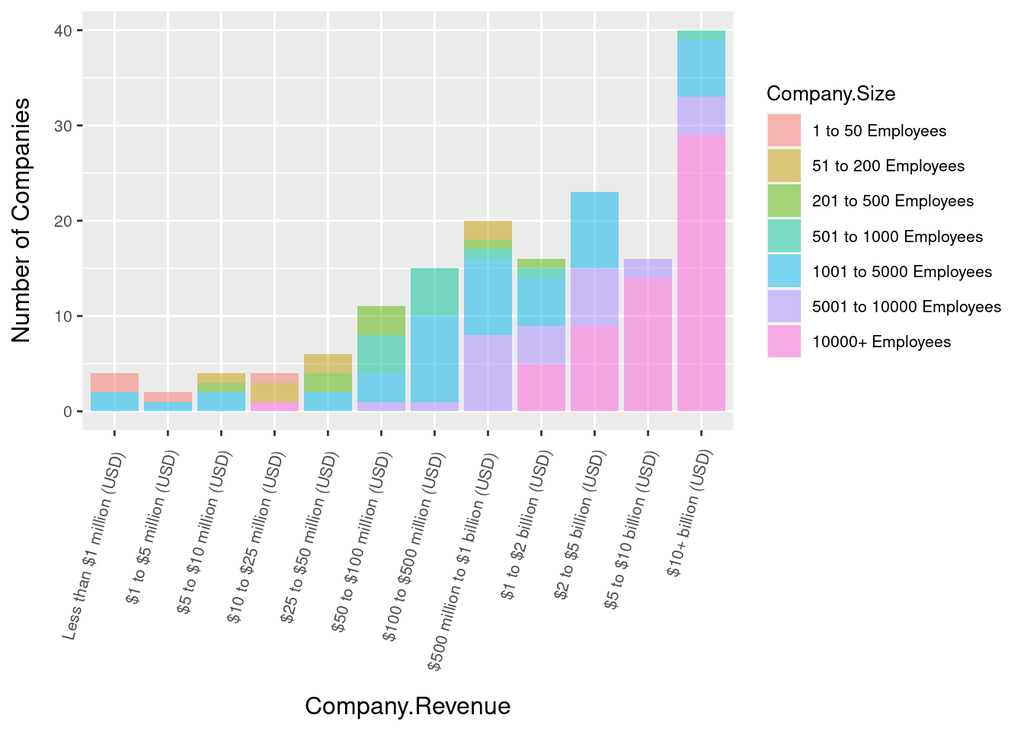

```r
ggplot(
  df[df$Company.Revenue != "Unknown / Non-Applicable" &
    !duplicated(df$Company), ]
) +
  geom_bar(
    aes(x = Company.Revenue, fill = Company.Size),
    alpha = 0.5
  ) +
  labs(y = "Number of Companies") +
  theme(
    axis.text.x = element_text(angle = 75, hjust = 1.05),
    axis.title = element_text(size = 16)
  ) +
  custom_theme(title_x_t_margin = 15, font_size = 10, label_size = 12)
```

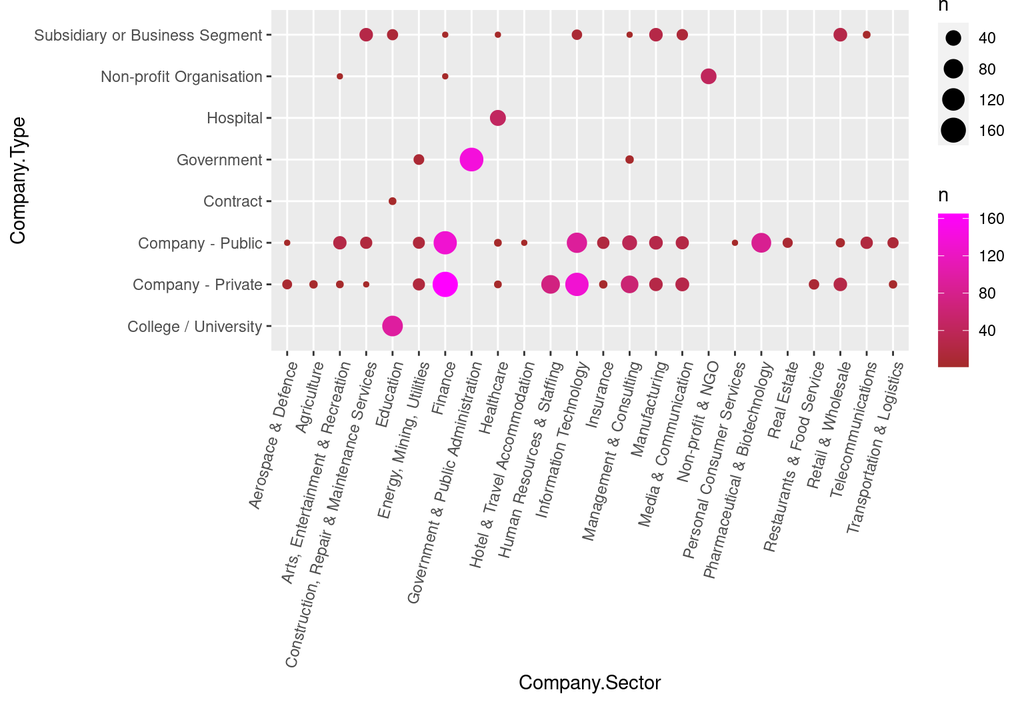

```r
ggplot(df[df$Company.Sector != "Unknown", ]) +
  geom_count(aes(x = Company.Sector, y = Company.Type, colour = ..n..)) +
  theme(axis.text.x = element_text(angle = 75, hjust = 1)) +
  scale_color_gradient(low = "brown", high = "magenta")
```

Plotting `Company Type` against `Company Sector`. Some make perfect sense for example all `College / University` are in `Education` and all `Hospital` are in `Healthcare`. Some are more interesting to look at like `Public` and `Private` as we can see they both have a big focus on `Finance` and `Information Technology` while `Public` companies also have an emphasis on `Pharmaceutical & Biotechnology` and `Private` companies are in `Human Resources & Staffing` sector where `Public` companies are not.

## 4.3 Salary

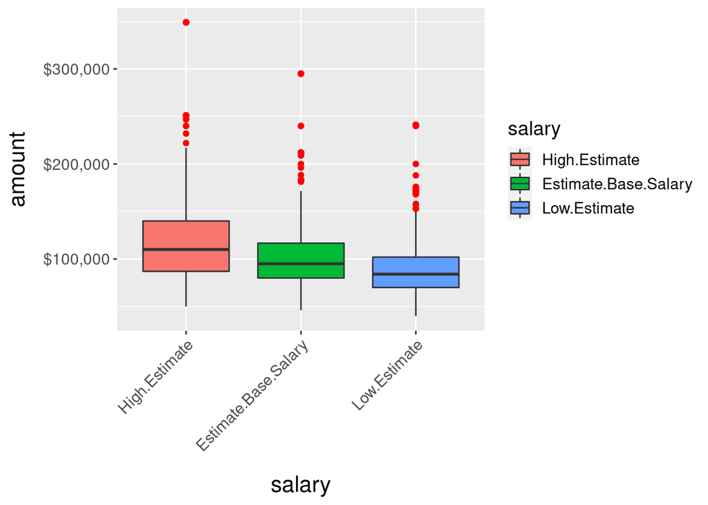

```r
salary_columns <- c("High.Estimate", "Estimate.Base.Salary", "Low.Estimate")
df_salary <- stack(df[salary_columns])
colnames(df_salary) <- c("amount", "salary")

ggplot(df_salary) +
  geom_boxplot(
    aes(x = salary, y = amount, fill = salary),
    outlier.colour = "red"
  ) +
  scale_y_continuous(labels = scales::dollar_format()) +
  theme(axis.text.x = element_text(angle = 45, hjust = 1)) +
  custom_theme(title_x_t_margin = 15)
```

As we can see from the box plot there are many outliers with really high starting salary and no outliers on the minimum wage. Since all 3 variables have similar distribution we’ll just use the `Estimate Base Salary` for base salaries from now on as it is more representative.

Let’s find out who the outliers are that offer such high base salary.

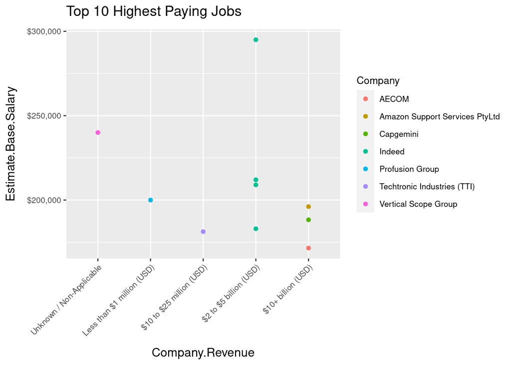

```r
df_salary <- df[
  !duplicated(df$Estimate.Base.Salary),
  c(
    "Company",
    "Estimate.Base.Salary",
    "Company.Revenue"
  )
]

df_salary[order(-df_salary$Estimate.Base.Salary), ] %>%
  head(10) %>%
  ggplot() +
    geom_point(aes(
      x = Company.Revenue,
      y = Estimate.Base.Salary,
      colour = Company
    )) +
    labs(title = "Top 10 Highest Paying Jobs") +
    scale_y_continuous(labels = scales::dollar_format()) +
    theme(axis.text.x = element_text(angle = 45, hjust = 1)) +
    custom_theme(
      title_b_margin = 10,
      title_size = 14,
      label_size = 12,
      font_size = 10
    )
```

Looks like a couple multi billion dollar companies are, especially `Indeed` who offers some of the highest income jobs, which makes sense as they have the revenue to do so. However majority of the jobs still have a starting salary of around $100,000 as shown by the histogram and density plot below.

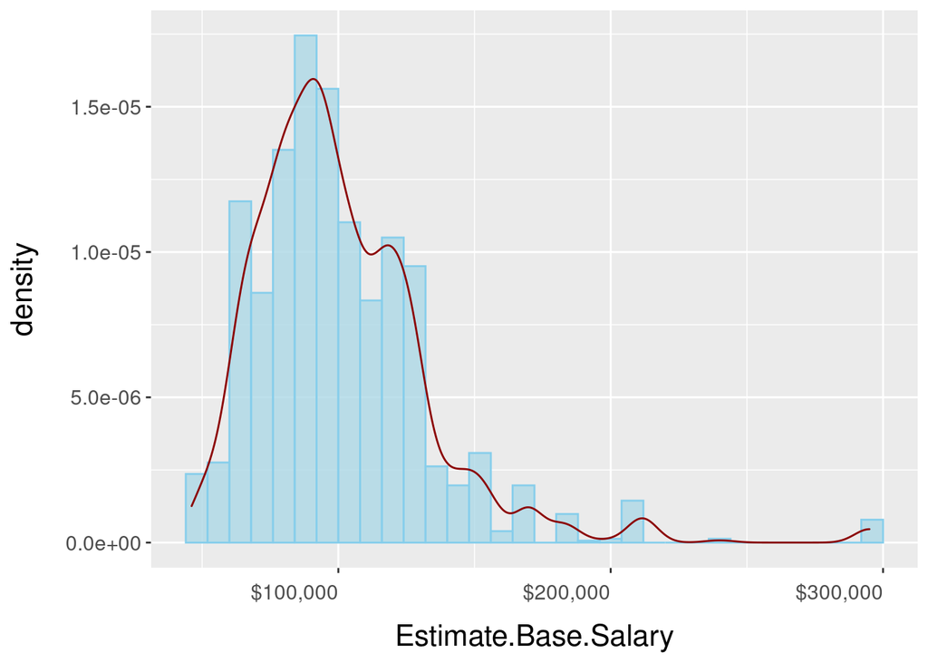

```r
ggplot(df, aes(x = Estimate.Base.Salary)) +
  geom_histogram(
    aes(y = ..density..),
    binwidth = 8000,
    alpha = 0.8,
    colour = "skyblue",
    fill = "lightblue"
  ) +
  geom_density(colour = "darkred") +
  scale_x_continuous(labels = scales::dollar_format()) +
  theme(axis.text.x = element_text(hjust = 1, vjust = -0.5)) +
  custom_theme(title_y_r_margin = 15, title_x_t_margin = 15)
```

## 4.4 Rating

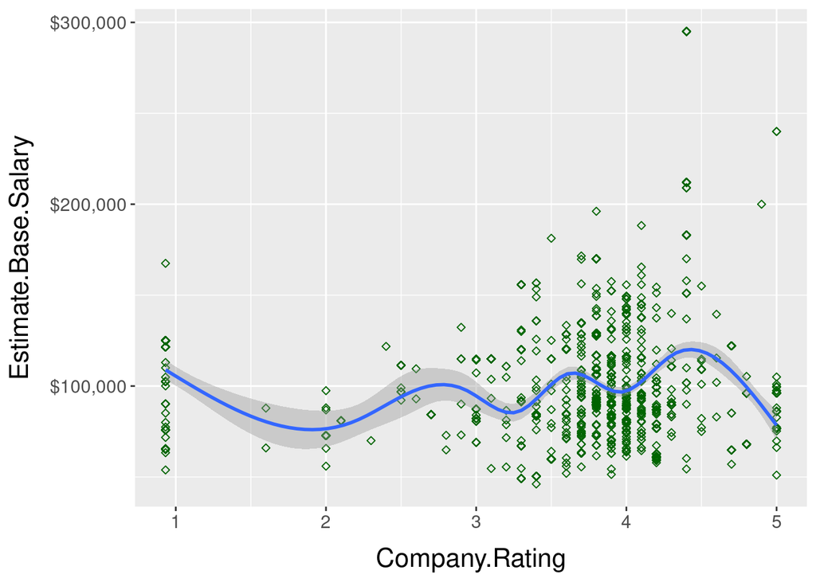

```r
ggplot(df, aes(x = Company.Rating, y = Estimate.Base.Salary)) +
  geom_point(colour = "darkgreen", shape = 23) +
  geom_smooth() +
  scale_y_continuous(labels = scales::dollar_format()) +
  custom_theme()
```

There is a small trend as the higher rating the company receives the higher base salary it pays, but the fitted curve is strongly affected by outliers as there are a lot of 5 star ratings that pay very low salary. This might be due to a portion of people who care more about other things like company culture than money.

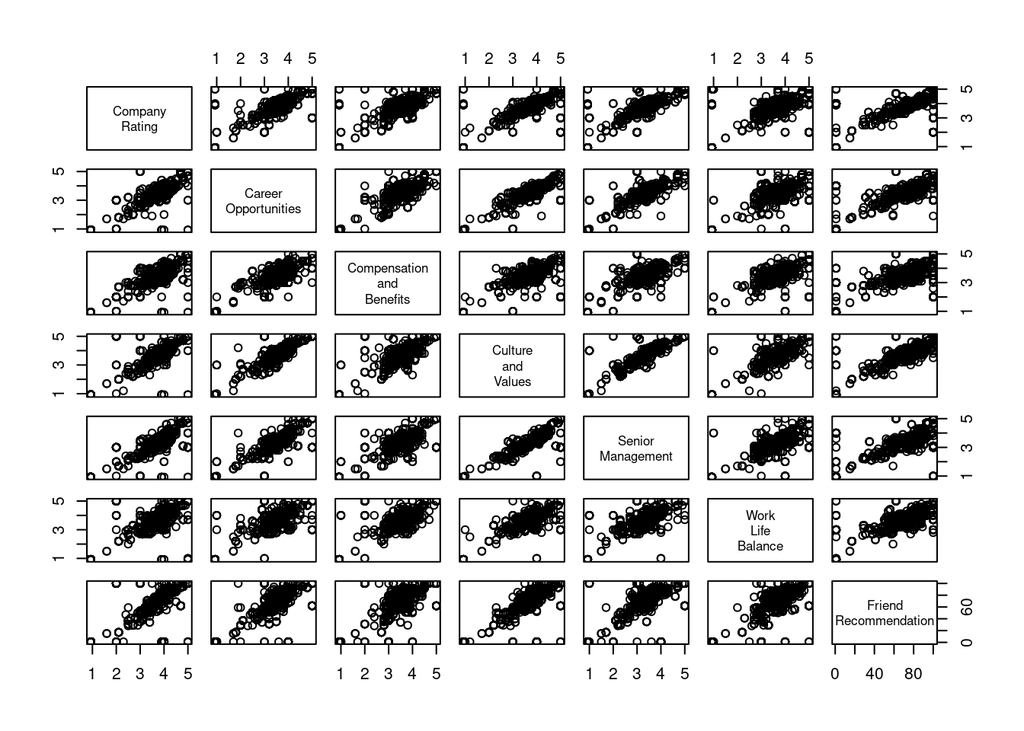

```r
df_ratings <- df[rating_columns]

# Replace dots with newlines so separate words are on different lines to fit in the scatter matrix
colnames(df_ratings) <- gsub("\\.", "\n", rating_columns)

pairs(df_ratings)
```

As suspected all the other criteria seem to be linearly correlated to the `Company Rating`, so the overall rating is more closely related to all the criteria than salary, ie. high salary does not necessarily give the company a good rating.

## 4.5 Skill

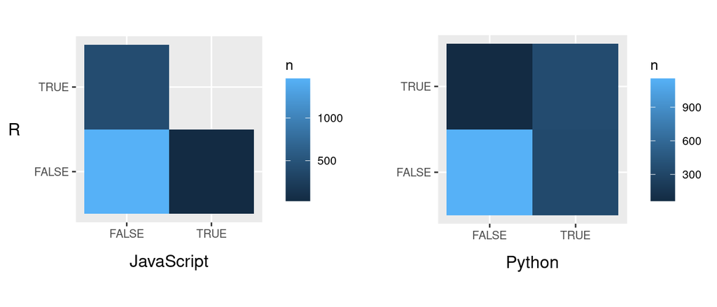

```r
javascript_r <- ggplot(
  count(df, javascript_yn, r_yn),
  aes(x = javascript_yn, y = r_yn),
) +
  geom_tile(aes(fill = n)) +
  coord_equal() +
  labs(y = "R", x = "JavaScript") +
  theme(axis.title.y = element_text(angle = 0, vjust = 0.5)) +
  custom_theme(font_size = 10, label_size = 12)

python_r <- ggplot(
  count(df, python_yn, r_yn),
  aes(x = python_yn, y = r_yn),
) +
  geom_tile(aes(fill = n)) +
  coord_equal() +
  labs(y = "", x = "Python") +
  custom_theme(font_size = 10, label_size = 12)

grid.arrange(javascript_r, python_r, ncol = 2)
```

```r
# Count the number of jobs that require JavaScript which also require R
sum(which(df$javascript_yn) %in% which(df$r_yn))
```

```
## [1] 0
```

Not a single job requires both `JavaScript` and `R` but there are a lot of overlaps between `Python` and `R`. There are more jobs that prefer `R` over `JavaScript` but `Python` over `R`.